# MLR Analysis - Data Loading & Preprocessing

Lingting

2026-06-26

# Overview

This notebook performs the initial data loading and preprocessing for the MLR (Mixed Lymphocyte Reaction) analysis pipeline. It processes immunoseq data from GVHD patients, calculates diversity metrics, identifies alloreactive and non-alloreactive clones, and prepares datasets for downstream analysis.

**Input:** Raw immunoseq files from patient folders in `Annotated_v4/`

**Output:** Processed `.rds` files saved to `data/processed/`

# Setup

## Load Configuration and Functions

```r
# Source configuration file (contains paths, parameters, package loading)
source("../config/config.R")
```

```
## Loading MLR Analysis configuration...
##
## ============================================================
## MLR Analysis Configuration Loaded Successfully
## ============================================================
## Data path:            /home/user/Documents/GVHD_project/MLR_analysis/Annotated_v4
## Excel metadata:       /home/user/Documents/GVHD_project/MLR_analysis/MLR_analysis_figure_1_2/TCR_Project.xlsx
## Output path:          /home/user/Documents/GVHD_project/MLR_analysis/MLR_analysis_figure_1_2/Main_fig
## Processed data path:  /home/user/Documents/GVHD_project/MLR_analysis/MLR_analysis_figure_1_2/data/processed
## Gold standard path:   /home/user/Documents/GVHD_project/MLR_analysis/MLR_analysis_figure_1_2/Main_fig_gold_standard
## Packages loaded:      23
## ============================================================
```

```r
# Source function definitions
source("../functions/mlr_functions.R")

# --- Redirect ALL outputs to separate "_corrected" folders so this notebook
# can NEVER overwrite anything in the original data/processed/ or Main_fig/
# directories. This notebook only differs from the original by a safeguard
# in the expansion-cutoff detection step (see "identify_expanded_clones" chunk)
# that fixes a degenerate result for Patient_098 without affecting anyone else.
PROCESSED_DATA_PATH <- file.path(FIGURE_1_2_DIR, "data/processed_corrected")
OUTPUT_PATH <- file.path(FIGURE_1_2_DIR, "Main_fig_corrected_dataloading")
dir.create(PROCESSED_DATA_PATH, showWarnings = FALSE, recursive = TRUE)
dir.create(OUTPUT_PATH, showWarnings = FALSE, recursive = TRUE)

cat("Configuration and functions loaded successfully!\n")
```

```
## Configuration and functions loaded successfully!
```

```r
cat("Data path:", DATA_PATH, "\n")
```

```
## Data path: /home/user/Documents/GVHD_project/MLR_analysis/Annotated_v4
```

```r
cat("Excel metadata:", EXCEL_PATH, "\n")
```

```
## Excel metadata: /home/user/Documents/GVHD_project/MLR_analysis/MLR_analysis_figure_1_2/TCR_Project.xlsx
```

```r
cat("Output directory (REDIRECTED):", PROCESSED_DATA_PATH, "\n")
```

```
## Output directory (REDIRECTED): /home/user/Documents/GVHD_project/MLR_analysis/MLR_analysis_figure_1_2/data/processed_corrected
```

## Initialize Data Structures

```r
# Get patient folders using absolute path (only Patient_* directories, excludes .DS_Store etc.)
filenames <- list.files(DATA_PATH, pattern = "^Patient_")
cat("Found", length(filenames), "patient folders:\n")
```

```
## Found 20 patient folders:
```

```r
print(filenames)
```

```
##  [1] "Patient_051" "Patient_066" "Patient_067" "Patient_068" "Patient_069"
##  [6] "Patient_070" "Patient_076" "Patient_081" "Patient_086" "Patient_090"
## [11] "Patient_091" "Patient_093" "Patient_098" "Patient_101" "Patient_137"
## [16] "Patient_143" "Patient_150" "Patient_153" "Patient_160" "Patient_179"
```

```r
# Initialize lists to store processed data
data <- vector("list", length(filenames))
data_meta <- vector("list", length(filenames))
all_allo <- vector("list", length(filenames))
all_nonallo <- vector("list", length(filenames))

# Define unique identifiers for clones
unique_identifiers <- UNIQUE_IDENTIFIERS

cat("\nUnique clone identifiers:", paste(unique_identifiers, collapse = ", "), "\n")
```

```
##
## Unique clone identifiers: cdr3_amino_acid, v_resolved, j_resolved
```

# Load Patient Data

## Process All Patient Folders

This step processes each patient’s immunoseq files by:

- Combining duplicate clones
- Merging CD4 and CD8 timepoints
- Identifying alloreactive vs. non-alloreactive clones
- Calculating clone frequencies

```r
cat("\n=== Processing Patient Data ===\n")
```

```
##
## === Processing Patient Data ===
```

```r
for (file_num in seq(1, length(filenames), 1)) {
  cat(sprintf("\nProcessing patient %d/%d: %s\n",
              file_num, length(filenames), filenames[file_num]))

  results <- process_data(filenames[file_num], DATA_PATH, unique_identifiers)

  data[[file_num]] <- results[[1]]        # immdata2
  data_meta[[file_num]] <- results[[2]]   # sample_meta_data
  all_allo[[file_num]] <- results[[3]]    # alloreactive clones
  all_nonallo[[file_num]] <- results[[4]] # non-alloreactive clones

  cat(sprintf("  - Loaded %d timepoints\n", length(data[[file_num]])))
  cat(sprintf("  - Found %d alloreactive clones\n", nrow(all_allo[[file_num]])))
  cat(sprintf("  - Found %d non-alloreactive clones\n", nrow(all_nonallo[[file_num]])))
}
```

```
##
## Processing patient 1/20: Patient_051
## [1] "Patient_051"
## Reading from: /home/user/Documents/GVHD_project/MLR_analysis/Annotated_v4/Patient_051
```

```
##   - Loaded 15 timepoints
##   - Found 6243 alloreactive clones
##   - Found 8176 non-alloreactive clones
##
## Processing patient 2/20: Patient_066
## [1] "Patient_066"
## Reading from: /home/user/Documents/GVHD_project/MLR_analysis/Annotated_v4/Patient_066
##   - Loaded 11 timepoints
##   - Found 3038 alloreactive clones
##   - Found 240223 non-alloreactive clones
##
## Processing patient 3/20: Patient_067
## [1] "Patient_067"
## Reading from: /home/user/Documents/GVHD_project/MLR_analysis/Annotated_v4/Patient_067
##   - Loaded 10 timepoints
##   - Found 3598 alloreactive clones
##   - Found 16616 non-alloreactive clones
##
## Processing patient 4/20: Patient_068
## [1] "Patient_068"
## Reading from: /home/user/Documents/GVHD_project/MLR_analysis/Annotated_v4/Patient_068
##   - Loaded 11 timepoints
##   - Found 1019 alloreactive clones
##   - Found 36367 non-alloreactive clones
##
## Processing patient 5/20: Patient_069
## [1] "Patient_069"
## Reading from: /home/user/Documents/GVHD_project/MLR_analysis/Annotated_v4/Patient_069
##   - Loaded 14 timepoints
##   - Found 3533 alloreactive clones
##   - Found 11696 non-alloreactive clones
##
## Processing patient 6/20: Patient_070
## [1] "Patient_070"
## Reading from: /home/user/Documents/GVHD_project/MLR_analysis/Annotated_v4/Patient_070
##   - Loaded 9 timepoints
##   - Found 3276 alloreactive clones
##   - Found 26416 non-alloreactive clones
##
## Processing patient 7/20: Patient_076
```

[output cut: 81 more lines]

```
##   - Found 120757 non-alloreactive clones
##
## Processing patient 19/20: Patient_160
## [1] "Patient_160"
## Reading from: /home/user/Documents/GVHD_project/MLR_analysis/Annotated_v4/Patient_160
##   - Loaded 9 timepoints
##   - Found 5810 alloreactive clones
##   - Found 97121 non-alloreactive clones
##
## Processing patient 20/20: Patient_179
## [1] "Patient_179"
## Reading from: /home/user/Documents/GVHD_project/MLR_analysis/Annotated_v4/Patient_179
##   - Loaded 8 timepoints
##   - Found 2358 alloreactive clones
##   - Found 375023 non-alloreactive clones
```

```r
cat("\n=== Patient Data Loading Complete ===\n")
```

```
##
## === Patient Data Loading Complete ===
```

## Summary of Loaded Data

```r
total_allo <- sum(sapply(all_allo, nrow))
total_nonallo <- sum(sapply(all_nonallo, nrow))
total_timepoints <- sum(sapply(data, length))

cat("\n--- Summary Statistics ---\n")
```

```
##
## --- Summary Statistics ---
```

```r
cat(sprintf("Total patients processed: %d\n", length(filenames)))
```

```
## Total patients processed: 20
```

```r
cat(sprintf("Total timepoints across all patients: %d\n", total_timepoints))
```

```
## Total timepoints across all patients: 192
```

```r
cat(sprintf("Total alloreactive clones identified: %d\n", total_allo))
```

```
## Total alloreactive clones identified: 51409
```

```r
cat(sprintf("Total non-alloreactive clones identified: %d\n", total_nonallo))
```

```
## Total non-alloreactive clones identified: 2145194
```

```r
cat(sprintf("Ratio (allo/non-allo): %.3f\n", total_allo / total_nonallo))
```

```
## Ratio (allo/non-allo): 0.024
```

# Load Metadata

## Load Patient Metadata (Load ONCE - not 8 times!)

**CRITICAL:** We load the clinical metadata ONLY ONCE here, avoiding the redundant loading that occurred in the original script.

```r
cat("\n=== Loading Patient Metadata ===\n")
```

```
##
## === Loading Patient Metadata ===
```

```r
# Load Patient Metadata sheet
meta_data <- read_excel(EXCEL_PATH, sheet = 'Patient Metadata') %>%
  mutate(
    PatientID = gsub("[^0-9.-]", "R", PatientID),
    PTCy = ifelse(grepl("PTCy", PTCy), "PTCy", "No PTCy")
  )

# Format to 29 patients
meta_data <- meta_data[1:29, ]
meta_data$PatientID <- paste("R", sprintf("%03d", as.integer(substring(meta_data$PatientID, 2))), sep = "")

cat(sprintf("Loaded metadata for %d patients\n", nrow(meta_data)))
```

```
## Loaded metadata for 29 patients
```

```r
# Load Patient Metadata cont. sheet (clinical data) - keep full sheet
clinical_data_full <- read_excel(EXCEL_PATH, sheet = "Patient Metadata cont.")
clinical_data_full$PatientID <- as.character(clinical_data_full$PatientID)

# Subset to columns used for diversity metrics calculations
clinical_data <- clinical_data_full[c('PatientID', 'Age_R', 'HLA_mis', 'DLI_PTD',
                                  'Relapse', 'Off Immunosuppresion',
                                  'GVHD_DX_Post_Transplant',
                                  'GVHD Max Grade Post Transplant',
                                  'EBV +', 'HHV6 +', 'Systemic_Steroids',
                                  'CMV +', "Chronic")]

clinical_data$PatientID <- as.character(clinical_data$PatientID)

cat(sprintf("Loaded clinical data for %d patients\n", nrow(clinical_data)))
```

```
## Loaded clinical data for 21 patients
```

## Merge Metadata

```r
# Merge patient metadata with clinical data
meta_data_clin <- dplyr::full_join(meta_data, clinical_data, by = "PatientID") %>%
  filter(!is.na(DonorType))

cat(sprintf("\nMerged metadata contains %d patients with complete information\n", nrow(meta_data_clin)))
```

```
##
## Merged metadata contains 29 patients with complete information
```

```r
cat("\nMetadata columns:\n")
```

```
##
## Metadata columns:
```

```r
print(colnames(meta_data_clin))
```

```
##  [1] "PatientID"                      "DonorType"
##  [3] "Disease"                        "PTCy"
##  [5] "Conditioning"                   "Sex"
##  [7] "DoT"                            "Onset"
##  [9] "GVHD_GRADE_1"                   "GVHD_GRADE_2"
## [11] "GVHD_GRADE_3"                   "GVHD_grade_14"
## [13] "GVHD_grade_24"                  "GVHD_grade_34"
## [15] "Steroid refractory GVHD"        "Reshef reviewed"
## [17] "Comment"                        "Age_R"
## [19] "HLA_mis"                        "DLI_PTD"
## [21] "Relapse"                        "Off Immunosuppresion"
## [23] "GVHD_DX_Post_Transplant"        "GVHD Max Grade Post Transplant"
## [25] "EBV +"                          "HHV6 +"
## [27] "Systemic_Steroids"              "CMV +"
## [29] "Chronic"
```

# Calculate Diversity Metrics

## Extract Full Alloreactive Clone Lists

```r
cat("\n=== Extracting Full Alloreactive Clones ===\n")
```

```
##
## === Extracting Full Alloreactive Clones ===
```

```r
all_full_allo <- vector("list", length(filenames))

for(i in seq(1, length(data), 1)) {
  allo <- all_allo[[i]]

  # Separate inner and outer alloreactive clones
  full_allo_inner <- subset(allo, allo$tag == 'inner')
  allo_inner <- full_allo_inner %>%
    subset(select = unique_identifiers)

  full_allo_outer <- subset(allo, allo$tag == 'outer')
  allo_outer <- full_allo_outer %>%
    subset(select = unique_identifiers)

  all_full_allo[[i]] <- bind_rows(full_allo_inner, full_allo_outer)

  cat(sprintf("Patient %d: %d inner + %d outer = %d total allo clones\n",
              i, nrow(full_allo_inner), nrow(full_allo_outer), nrow(all_full_allo[[i]])))
}
```

```
## Patient 1: 0 inner + 6243 outer = 6243 total allo clones
## Patient 2: 125 inner + 2913 outer = 3038 total allo clones
## Patient 3: 98 inner + 3500 outer = 3598 total allo clones
## Patient 4: 177 inner + 842 outer = 1019 total allo clones
## Patient 5: 62 inner + 3471 outer = 3533 total allo clones
## Patient 6: 80 inner + 3196 outer = 3276 total allo clones
## Patient 7: 48 inner + 1450 outer = 1498 total allo clones
## Patient 8: 49 inner + 251 outer = 300 total allo clones
## Patient 9: 210 inner + 1118 outer = 1328 total allo clones
## Patient 10: 116 inner + 2235 outer = 2351 total allo clones
## Patient 11: 330 inner + 406 outer = 736 total allo clones
## Patient 12: 204 inner + 4662 outer = 4866 total allo clones
## Patient 13: 231 inner + 1307 outer = 1538 total allo clones
## Patient 14: 84 inner + 569 outer = 653 total allo clones
## Patient 15: 167 inner + 1924 outer = 2091 total allo clones
## Patient 16: 3 inner + 253 outer = 256 total allo clones
## Patient 17: 271 inner + 6334 outer = 6605 total allo clones
## Patient 18: 33 inner + 279 outer = 312 total allo clones
## Patient 19: 266 inner + 5544 outer = 5810 total allo clones
## Patient 20: 587 inner + 1771 outer = 2358 total allo clones
```

## Shannon Entropy, Gini-Simpson, Clone Fraction

This step calculates diversity metrics for:

- All clones
- Alloreactive clones (CD4, CD8, and combined)
- Non-alloreactive clones (CD4, CD8, and combined)
- Inner vs. outer alloreactive clones

```r
cat("\n=== Calculating Diversity Metrics ===\n")
```

```
##
## === Calculating Diversity Metrics ===
```

```r
# Initialize storage lists for diversity calculations
data_all <- vector("list", length(filenames))
data_allo <- vector("list", length(filenames))
data_allo_w0 <- vector("list", length(filenames))
data_allo_inner <- vector("list", length(filenames))
data_allo_outer <- vector("list", length(filenames))
data_allo_10 <- vector("list", length(filenames))
data_nonallo <- vector("list", length(filenames))
data_nonallo_w0 <- vector("list", length(filenames))

all_allo_div <- vector("list", length(filenames))
all_allo_div_CD4 <- vector("list", length(filenames))
all_allo_div_CD8 <- vector("list", length(filenames))
all_allo_inner_div <- vector("list", length(filenames))
all_allo_outer_div <- vector("list", length(filenames))
all_nonallo_div <- vector("list", length(filenames))
all_nonallo_div_CD4 <- vector("list", length(filenames))
all_nonallo_div_CD8 <- vector("list", length(filenames))
all_rep_div <- vector("list", length(filenames))

# Iterate through each patient and calculate diversity metrics
for(i in seq(1, length(data), 1)) {
  cat(sprintf("\nCalculating diversity for patient %d/%d: %s\n",
              i, length(data), filenames[i]))

  immdata2 <- data[[i]]
  allo <- all_allo[[i]]
  nonallo <- all_nonallo[[i]]
  sample_meta_data <- data_meta[[i]]

  # Separate inner and outer alloreactive clones
  full_allo_inner <- subset(allo, allo$tag == 'inner')
  allo_inner <- full_allo_inner %>%
    subset(select = c(unique_identifiers, "PatientID"))

  full_allo_outer <- subset(allo, allo$tag == 'outer')
  allo_outer <- full_allo_outer %>%
    subset(select = c(unique_identifiers, "PatientID"))

  # Separate CD4 and CD8 clones for alloreactive
  allo <- allo %>% subset(select = c(unique_identifiers, "cell_type"))
  allo_CD4 <- allo[grepl("4", allo$cell_type) & !grepl("8", allo$cell_type), ]
  allo_CD8 <- allo[grepl("8", allo$cell_type) & !grepl("4", allo$cell_type), ]

  # Separate CD4 and CD8 clones for non-alloreactive
  nonallo <- nonallo %>%
    subset(select = c(unique_identifiers, "cell_type", "PatientID"))
  nonallo_CD4 <- nonallo[grepl("4", nonallo$cell_type) & !grepl("8", nonallo$cell_type), ]
  nonallo_CD8 <- nonallo[grepl("8", nonallo$cell_type) & !grepl("4", nonallo$cell_type), ]

  # Combine all clones
  all <- bind_rows(allo, nonallo)
  immdata_all <- lapply(immdata2, function(x) {
    x %>%
      dplyr::inner_join(all, by = unique_identifiers) %>%
      mutate(cell_type = cell_type.y) %>%
      subset(select = -c(cell_type.x, cell_type.y))
  })

  # Calculate repertoire diversity for all clones
  all_rep_div[[i]] <- repertoire_diversity(immdata_all)

  # Create datasets with only alloreactive clones
  immdata_alloreactives <- lapply(immdata2, function(x) {
    x %>%
      dplyr::inner_join(allo, by = unique_identifiers) %>%
      mutate(cell_type = cell_type.y) %>%
      subset(select = -c(cell_type.x, cell_type.y))
  })

  # Alloreactive with zeros (w0) for timepoints without specific clones
  immdata_alloreactives_w0 <- lapply(immdata2, function(x) {
    curr_timepoint <- unique(x$timepoint)
    x %>%
      dplyr::right_join(allo, by = unique_identifiers) %>%
      mutate(
        cell_type = ifelse(is.na(cell_type.y), "CD4 CD8", cell_type.y),
        templates = ifelse(is.na(templates), 0, templates),
        frequency = ifelse(is.na(frequency), 0, frequency),
        PatientID = sample_meta_data[1, 1],
        timepoint = curr_timepoint
      ) %>%
      subset(select = -c(cell_type.x, cell_type.y))
  })

  # Alloreactive CD4 and CD8
  immdata_alloreactives_CD4 <- lapply(immdata2, function(x) {
    x %>%
      dplyr::inner_join(allo_CD4, by = unique_identifiers) %>%
      mutate(cell_type = cell_type.y) %>%
      subset(select = -c(cell_type.x, cell_type.y))
  })

  immdata_alloreactives_CD8 <- lapply(immdata2, function(x) {
    x %>%
      dplyr::inner_join(allo_CD8, by = unique_identifiers) %>%
      mutate(cell_type = cell_type.y) %>%
      subset(select = -c(cell_type.x, cell_type.y))
  })

  # Calculate diversity for alloreactive clones
  all_allo_div[[i]] <- repertoire_diversity(immdata_alloreactives)
  all_allo_div_CD4[[i]] <- repertoire_diversity(immdata_alloreactives_CD4)
  all_allo_div_CD8[[i]] <- repertoire_diversity(immdata_alloreactives_CD8)

  # Inner alloreactive clones
  immdata_alloreactives_inner <- lapply(immdata2, function(x) {
    x <- dplyr::inner_join(allo_inner, x, by = unique_identifiers)
  })
  all_allo_inner_div[[i]] <- repertoire_diversity(immdata_alloreactives_inner)

  # Outer alloreactive clones
  immdata_alloreactives_outer <- lapply(immdata2, function(x) {
    x <- dplyr::inner_join(allo_outer, x, by = unique_identifiers)
  })
  all_allo_outer_div[[i]] <- repertoire_diversity(immdata_alloreactives_outer)

  # Non-alloreactive clones
  immdata_nonalloreactives <- lapply(immdata2, function(x) {
    x %>%
      dplyr::inner_join(nonallo, by = unique_identifiers) %>%
      mutate(cell_type = cell_type.y) %>%
      subset(select = -c(cell_type.x, cell_type.y))
  })

  immdata_nonalloreactives_CD4 <- lapply(immdata2, function(x) {
    x %>%
      dplyr::inner_join(nonallo_CD4, by = unique_identifiers) %>%
      mutate(cell_type = cell_type.y) %>%
      subset(select = -c(cell_type.x, cell_type.y))
  })

  immdata_nonalloreactives_CD8 <- lapply(immdata2, function(x) {
    x %>%
      dplyr::inner_join(nonallo_CD8, by = unique_identifiers) %>%
      mutate(cell_type = cell_type.y) %>%
      subset(select = -c(cell_type.x, cell_type.y))
  })

  # Non-alloreactive with zeros
  immdata_nonalloreactives_w0 <- lapply(seq_along(immdata2), function(x) {
    immdata2[[x]] %>%
      dplyr::right_join(nonallo, by = c(unique_identifiers, "PatientID")) %>%
      mutate(
        cell_type = cell_type.y,
        templates = ifelse(is.na(templates), 0, templates),
        frequency = ifelse(is.na(frequency), 0, frequency),
        PatientID = strsplit(names(immdata2)[x], "_")[[1]][1],
        timepoint = strsplit(names(immdata2)[x], "_")[[1]][2]
      ) %>%
      subset(select = -c(cell_type.x, cell_type.y))
  })
  names(immdata_nonalloreactives_w0) <- names(immdata2)

  # Calculate diversity for non-alloreactive clones
  all_nonallo_div[[i]] <- repertoire_diversity(immdata_nonalloreactives)
  all_nonallo_div_CD4[[i]] <- repertoire_diversity(immdata_nonalloreactives_CD4)
  all_nonallo_div_CD8[[i]] <- repertoire_diversity(immdata_nonalloreactives_CD8)

  # Top 10 clones
  immdata_nonalloreactives_top10 <- lapply(immdata2, function(x) {
    x %>%
      dplyr::anti_join(allo, by = unique_identifiers) %>%
      arrange(desc(frequency)) %>%
      slice_head(n = 10)
  })

  immdata_alloreactives_top10 <- lapply(immdata2, function(x) {
    x %>%
      dplyr::inner_join(allo, by = unique_identifiers) %>%
      arrange(desc(frequency)) %>%
      slice_head(n = 10)
  })

  # Store results
  data_all[[i]] <- immdata_all
  data_nonallo[[i]] <- immdata_nonalloreactives
  data_nonallo_w0[[i]] <- immdata_nonalloreactives_w0
  data_allo[[i]] <- immdata_alloreactives
  data_allo_w0[[i]] <- immdata_alloreactives_w0
  data_allo_inner[[i]] <- immdata_alloreactives_inner
  data_allo_outer[[i]] <- immdata_alloreactives_outer
  data_allo_10[[i]] <- immdata_alloreactives_top10

  cat(sprintf("  - All clones diversity: %d samples\n", length(immdata_all)))
  cat(sprintf("  - Allo diversity: %d samples\n", length(immdata_alloreactives)))
  cat(sprintf("  - Non-allo diversity: %d samples\n", length(immdata_nonalloreactives)))
}
```

```
##
## Calculating diversity for patient 1/20: Patient_051
##   - All clones diversity: 15 samples
##   - Allo diversity: 15 samples
##   - Non-allo diversity: 15 samples
##
## Calculating diversity for patient 2/20: Patient_066
##   - All clones diversity: 11 samples
##   - Allo diversity: 11 samples
##   - Non-allo diversity: 11 samples
##
## Calculating diversity for patient 3/20: Patient_067
##   - All clones diversity: 10 samples
##   - Allo diversity: 10 samples
##   - Non-allo diversity: 10 samples
##
## Calculating diversity for patient 4/20: Patient_068
##   - All clones diversity: 11 samples
##   - Allo diversity: 11 samples
##   - Non-allo diversity: 11 samples
##
## Calculating diversity for patient 5/20: Patient_069
##   - All clones diversity: 14 samples
##   - Allo diversity: 14 samples
##   - Non-allo diversity: 14 samples
##
## Calculating diversity for patient 6/20: Patient_070
##   - All clones diversity: 9 samples
##   - Allo diversity: 9 samples
##   - Non-allo diversity: 9 samples
##
## Calculating diversity for patient 7/20: Patient_076
##   - All clones diversity: 7 samples
##   - Allo diversity: 7 samples
##   - Non-allo diversity: 7 samples
##
## Calculating diversity for patient 8/20: Patient_081
##   - All clones diversity: 13 samples
##   - Allo diversity: 13 samples
##   - Non-allo diversity: 13 samples
```

[output cut: 45 more lines]

```
##
## Calculating diversity for patient 18/20: Patient_153
##   - All clones diversity: 8 samples
##   - Allo diversity: 8 samples
##   - Non-allo diversity: 8 samples
##
## Calculating diversity for patient 19/20: Patient_160
##   - All clones diversity: 9 samples
##   - Allo diversity: 9 samples
##   - Non-allo diversity: 9 samples
##
## Calculating diversity for patient 20/20: Patient_179
##   - All clones diversity: 8 samples
##   - Allo diversity: 8 samples
##   - Non-allo diversity: 8 samples
```

```r
cat("\n=== Diversity Calculation Complete ===\n")
```

```
##
## === Diversity Calculation Complete ===
```

# Identify Expanded Clones

Using the elbow method (curvature detection) to identify expanded clones based on frequency distributions.

```r
cat("\n=== Identifying Expanded Clones ===\n")
```

```
##
## === Identifying Expanded Clones ===
```

```
##
## Processing patient 1/20: Patient_051
```

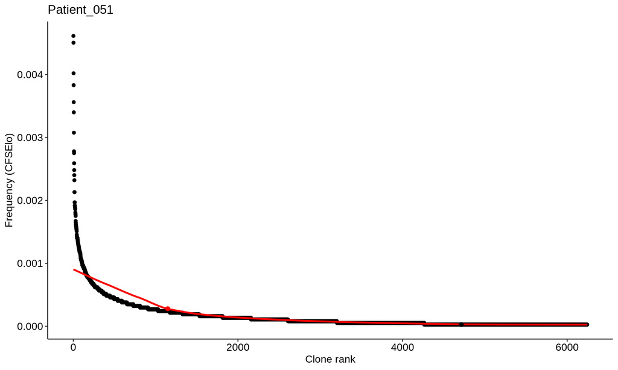

```
##   - Found 907 expanded clones (cutoff frequency: 0.000280)
##
## Processing patient 2/20: Patient_066
```

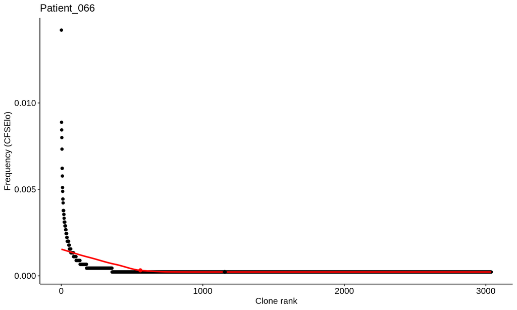

```
##   - Found 358 expanded clones (cutoff frequency: 0.000319)
##
## Processing patient 3/20: Patient_067
```

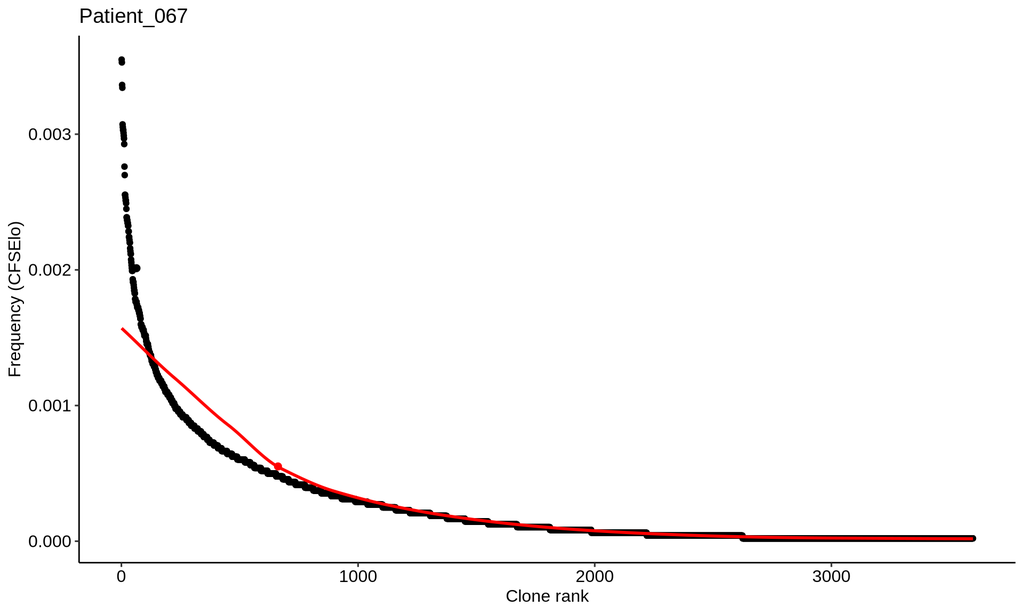

```
##   - Found 561 expanded clones (cutoff frequency: 0.000551)
##
## Processing patient 4/20: Patient_068
```

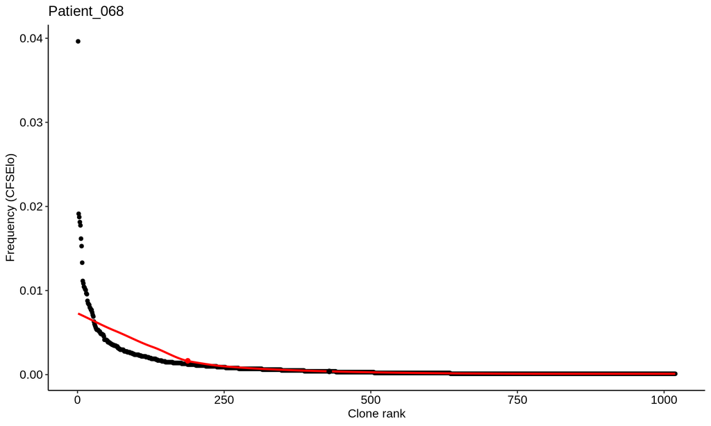

```
##   - Found 143 expanded clones (cutoff frequency: 0.001639)
##
## Processing patient 5/20: Patient_069
```

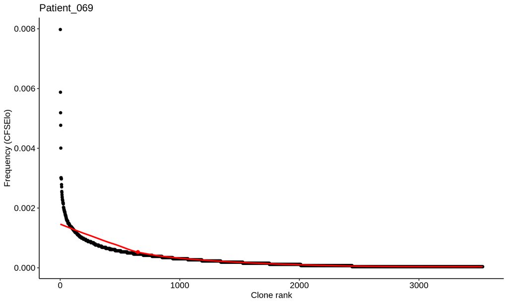

```
##   - Found 559 expanded clones (cutoff frequency: 0.000527)
##
## Processing patient 6/20: Patient_070
```

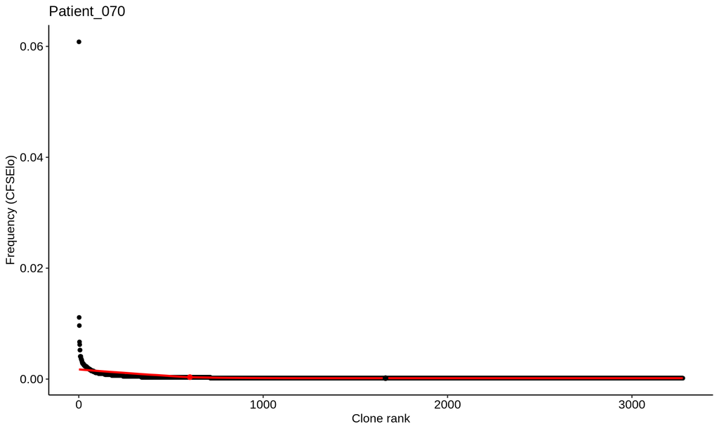

```
##   - Found 339 expanded clones (cutoff frequency: 0.000350)
##
## Processing patient 7/20: Patient_076
```

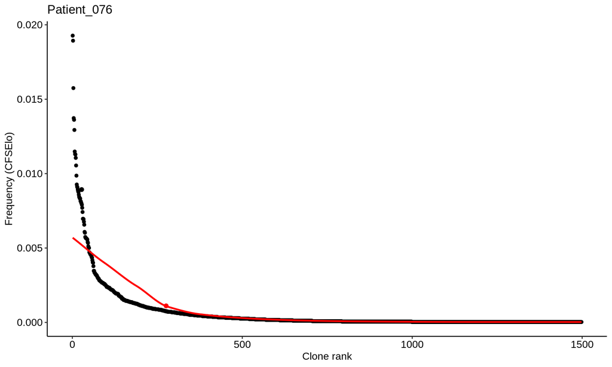

```
##   - Found 203 expanded clones (cutoff frequency: 0.001113)
##
## Processing patient 8/20: Patient_081
```

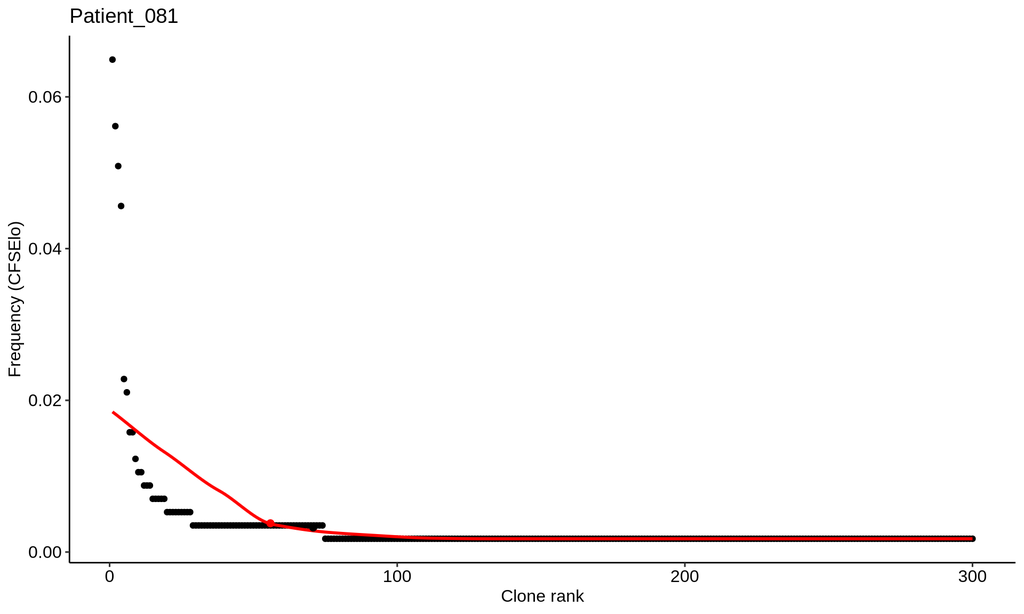

```
##   - Found 28 expanded clones (cutoff frequency: 0.003793)
##
## Processing patient 9/20: Patient_086
```

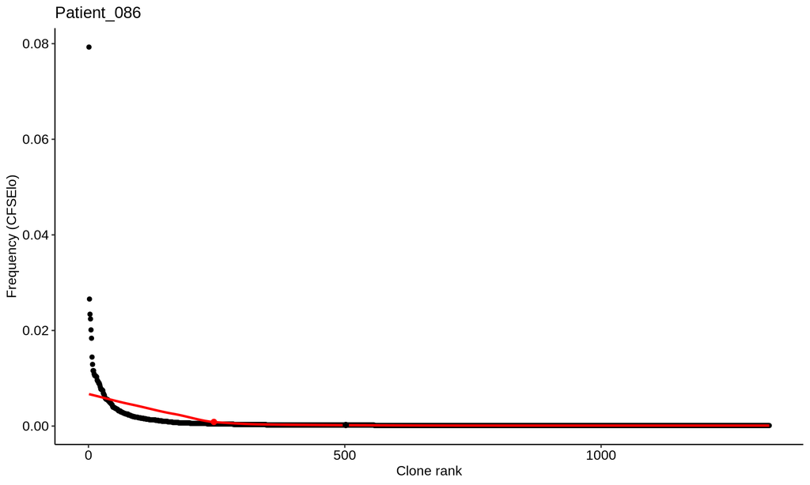

```
##   - Found 163 expanded clones (cutoff frequency: 0.000866)
##
## Processing patient 10/20: Patient_090
```

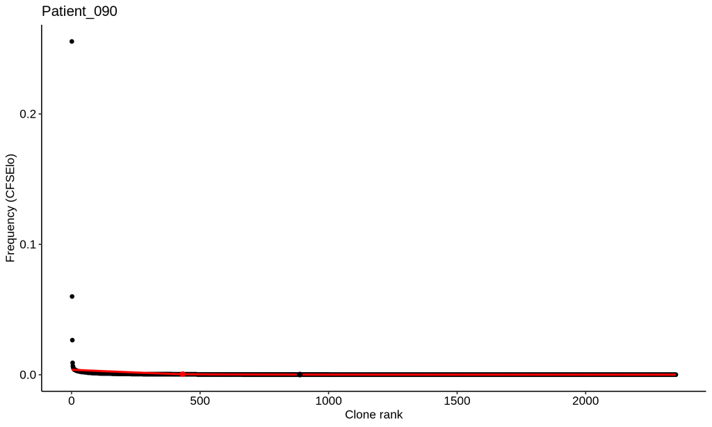

```
##   - Found 317 expanded clones (cutoff frequency: 0.000478)
##
## Processing patient 11/20: Patient_091
```

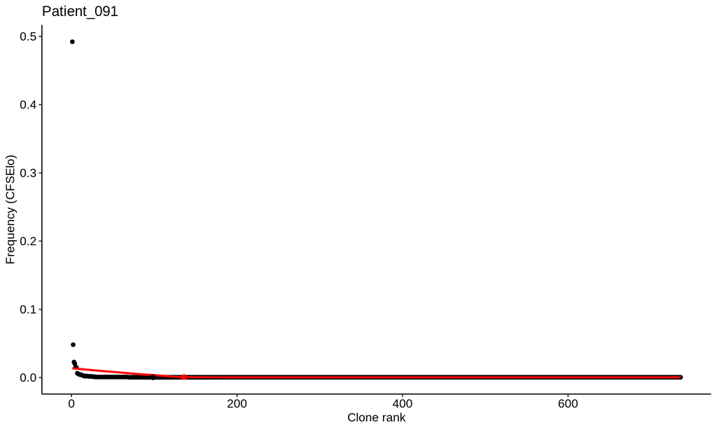

```
##   - Found 68 expanded clones (cutoff frequency: 0.000732)
##
## Processing patient 12/20: Patient_093
```

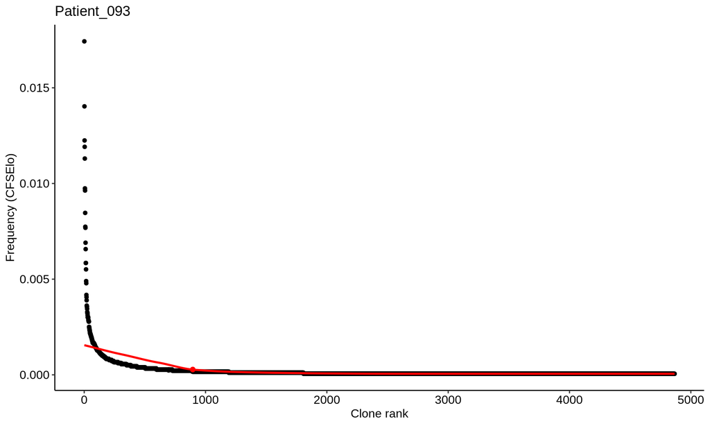

```
##   - Found 594 expanded clones (cutoff frequency: 0.000279)
##
## Processing patient 13/20: Patient_098
##   [SAFEGUARD] Patient_098: unconstrained curvature cutoff was degenerate (selected 100% of clones); falling back to restricted search (first 30% of ranks).
```

[8 more figures not shown]

```
##   - Found 272 expanded clones (cutoff frequency: 0.000430)
```

```r
full_allo_input <- all_full_allo
elbow <- vector("list", length(filenames))
expanded_clones <- vector("list", length(filenames))

# Per-patient elbow plots also live in Figure1ex/elbow_plots/ (in addition to
# OUTPUT_PATH above) so they're discoverable alongside the other supplementary
# figures rather than only in this notebook's own redirected output folder.
ELBOW_PLOTS_PATH <- file.path(FIGURE_1_2_DIR, "Main_fig", "Figure1ex", "elbow_plots")
dir.create(ELBOW_PLOTS_PATH, showWarnings = FALSE, recursive = TRUE)

for(i in seq(1, length(data), 1)) {
  cat(sprintf("\nProcessing patient %d/%d: %s\n", i, length(data), filenames[i]))

  full_allo <- full_allo_input[[i]]
  allo_cd48 <- full_allo

  # Sort by frequency
  sorted_CD48_allo <- allo_cd48[order(-allo_cd48$frequency.CFSELo), ]

  # Find cutoff using simple method
  simple_cutoff <- data.frame(findCutoff(as.numeric(rownames(sorted_CD48_allo)),
                                          sorted_CD48_allo$frequency.CFSELo))

  # Fit loess curve and find cutoff using curvature method
  lo <- loess(sorted_CD48_allo$frequency.CFSELo ~ as.numeric(rownames(sorted_CD48_allo)),
              span = 0.4, degree = 1)
  line_data <- data.frame(y = predict(lo), x = seq_along(predict(lo)))
  ranks_i <- as.numeric(rownames(sorted_CD48_allo))
  pred_i <- predict(lo, ranks_i)
  lo_cutoff <- data.frame(findCutoff(ranks_i, pred_i, method = "curvature"))

  # --- Safeguard against degenerate curvature-detection results ---
  # For patients with a very long, flat, low-variance tail, the curvature method
  # can fail to find a real elbow and instead select a point so far into the tail
  # that it includes nearly all clones (e.g. Patient_098 originally selected 100%
  # of clones as "expanded"). Every other patient's true elbow was independently
  # confirmed to fall within the first ~30% of their rank range, so we use that
  # as a sane search window only when the unconstrained result is degenerate
  # (selects >=90% of all clones) -- this never changes the result for patients
  # whose unconstrained curvature detection already succeeds.
  used_fallback <- FALSE
  n_exp_check <- sum(sorted_CD48_allo$frequency.CFSELo >= lo_cutoff$y)
  if (n_exp_check / nrow(sorted_CD48_allo) >= 0.9) {
    used_fallback <- TRUE
    restricted_n <- ceiling(0.3 * length(ranks_i))
    lo_cutoff <- data.frame(findCutoff(ranks_i[1:restricted_n], pred_i[1:restricted_n],
                                        method = "curvature"))
    cat(sprintf("  [SAFEGUARD] %s: unconstrained curvature cutoff was degenerate (selected %.0f%% of clones); falling back to restricted search (first 30%% of ranks).\n",
                filenames[i], 100*n_exp_check/nrow(sorted_CD48_allo)))
  }

  # Create plot showing expanded clone cutoff
  expanded_plot <- ggplot(sorted_CD48_allo, aes(x = seq_along(frequency.CFSELo), y = frequency.CFSELo)) +
    geom_point() +
    geom_line(data = line_data, color = "red", size = 1, aes(x = x, y = y)) +
    geom_point(data = simple_cutoff, color = "black", size = 2, aes(x = x, y = y)) +
    geom_point(data = lo_cutoff, color = if (used_fallback) "blue" else "red", size = 2, aes(x = x, y = y)) +
    theme_pubr() +
    labs(title = paste0(filenames[i], if (used_fallback) " (safeguard applied)" else ""),
         x = "Clone rank",
         y = "Frequency (CFSElo)")

  print(expanded_plot)

  # Save plots
  ggsave(filename = file.path(OUTPUT_PATH, paste0("expanded_plot_", filenames[i], ".png")),
         plot = expanded_plot, width = 4, height = 3, units = "in", dpi = 300)
  ggsave(filename = file.path(OUTPUT_PATH, paste0("expanded_plot_", filenames[i], ".pdf")),
         plot = expanded_plot, width = 4, height = 3, units = "in", dpi = 300)
  ggsave(filename = file.path(ELBOW_PLOTS_PATH, paste0("expanded_plot_", filenames[i], ".png")),
         plot = expanded_plot, width = 4, height = 3, units = "in", dpi = 300)
  ggsave(filename = file.path(ELBOW_PLOTS_PATH, paste0("expanded_plot_", filenames[i], ".pdf")),
         plot = expanded_plot, width = 4, height = 3, units = "in", dpi = 300)

  # Store elbow point and expanded clones (using the safeguarded cutoff)
  elbow[[i]] <- list(x = lo_cutoff$x, y = lo_cutoff$y)
  top_allo_48 <- allo_cd48[allo_cd48$frequency.CFSELo >= elbow[[i]]$y, ]
  expanded_clones[[i]] <- top_allo_48

  cat(sprintf("  - Found %d expanded clones (cutoff frequency: %.6f)\n",
              nrow(top_allo_48), elbow[[i]]$y))
}
```

```r
cat("\n=== Expanded Clone Identification Complete ===\n")
```

```
##
## === Expanded Clone Identification Complete ===
```

# Create Combined Datasets

## Add Clone Tags and Expansion Status

```r
cat("\n=== Adding Clone Tags and Expansion Status ===\n")
```

```
##
## === Adding Clone Tags and Expansion Status ===
```

```r
# Add CDR3-V-J tag to alloreactive clones
data_allo <- map(data_allo, function(list1) {
  map(list1, ~ mutate(.x, tag = paste(cdr3_amino_acid, v_resolved, j_resolved, sep = " ")))
})

data_allo_w0 <- map(data_allo_w0, function(list1) {
  map(list1, ~ mutate(.x, tag = paste(cdr3_amino_acid, v_resolved, j_resolved, sep = " ")))
})

# Add tags to expanded clones
expanded_clones <- map(expanded_clones, ~ mutate(.x, tag = paste(cdr3_amino_acid, v_resolved, j_resolved, sep = " ")))

# Map expansion status to data_allo
for (i in 1:length(data_allo)) {
  for (j in 1:length(data_allo[[i]])) {
    data_allo[[i]][[j]] <- data_allo[[i]][[j]] %>%
      mutate(ifexpanded = ifelse(tag %in% expanded_clones[[i]]$tag, TRUE, FALSE))
  }
}

# Map expansion status to data_allo_w0
for (i in 1:length(data_allo_w0)) {
  for (j in 1:length(data_allo_w0[[i]])) {
    data_allo_w0[[i]][[j]] <- data_allo_w0[[i]][[j]] %>%
      mutate(ifexpanded = ifelse(tag %in% expanded_clones[[i]]$tag, TRUE, FALSE))
  }
}

cat("Clone tags and expansion status added successfully\n")
```

```
## Clone tags and expansion status added successfully
```

## Squish Data Across Patients

Combine data across all patients into unified datasets.

```r
cat("\n=== Creating Combined Datasets ===\n")
```

```
##
## === Creating Combined Datasets ===
```

```r
# Squish alloreactive data
data_allo_squished <- lapply(data_allo, function(x) {
  bind_rows(x)
})
data_allo_squished <- bind_rows(data_allo_squished)
data_allo_squished$allo <- TRUE

cat(sprintf("Alloreactive squished: %d rows\n", nrow(data_allo_squished)))
```

```
## Alloreactive squished: 65988 rows
```

```r
# Squish non-alloreactive data
data_nonallo_squished <- lapply(data_nonallo, function(x) {
  bind_rows(x)
})
data_nonallo_squished <- bind_rows(data_nonallo_squished)
data_nonallo_squished$allo <- FALSE
data_nonallo_squished$ifexpanded <- FALSE

cat(sprintf("Non-alloreactive squished: %d rows\n", nrow(data_nonallo_squished)))
```

```
## Non-alloreactive squished: 2454714 rows
```

```r
# Combine all clones (allo + non-allo)
data_squished <- bind_rows(data_allo_squished, data_nonallo_squished)
data_squished_meta <- dplyr::inner_join(data_squished, meta_data_clin, by = "PatientID")

cat(sprintf("Combined all clones: %d rows\n", nrow(data_squished)))
```

```
## Combined all clones: 2520702 rows
```

```r
cat(sprintf("Combined with metadata: %d rows\n", nrow(data_squished_meta)))
```

```
## Combined with metadata: 65988 rows
```

```r
# Squish with zeros (w0)
data_allo_squished_w0 <- lapply(data_allo_w0, function(x) {
  bind_rows(x)
})
data_allo_squished_w0 <- bind_rows(data_allo_squished_w0)
data_allo_squished_w0$type <- "allo"

cat(sprintf("Alloreactive w0: %d rows\n", nrow(data_allo_squished_w0)))
```

```
## Alloreactive w0: 520482 rows
```

```r
data_nonallo_squished_w0 <- lapply(data_nonallo_w0, function(x) {
  bind_rows(x)
})
data_nonallo_squished_w0 <- bind_rows(data_nonallo_squished_w0)
data_nonallo_squished_w0$type <- "nonallo"
data_nonallo_squished_w0$ifexpanded <- FALSE

cat(sprintf("Non-alloreactive w0: %d rows\n", nrow(data_nonallo_squished_w0)))
```

```
## Non-alloreactive w0: 20208138 rows
```

```r
# Combine with zeros
data_squished_w0 <- bind_rows(data_allo_squished_w0, data_nonallo_squished_w0)
data_squished_meta_w0 <- dplyr::inner_join(data_squished_w0, meta_data_clin, by = "PatientID")

cat(sprintf("Combined w0: %d rows\n", nrow(data_squished_w0)))
```

```
## Combined w0: 20728620 rows
```

```r
cat(sprintf("Combined w0 with metadata: %d rows\n", nrow(data_squished_meta_w0)))
```

```
## Combined w0 with metadata: 20728620 rows
```

```r
# CD4/CD8 alloreactive dataset
cd48_allo <- vector("list", length(filenames))
for (file_num in seq_along(filenames)) {
  cd48_allo[[file_num]] <- vector("list", length(data_allo_w0[[file_num]]))

  for (i in seq_along(data_allo_w0[[file_num]])) {
    cd48_allo[[file_num]][[i]] <- data_allo_w0[[file_num]][[i]] %>%
      mutate(ifexpanded = as.character(ifexpanded))
  }
}

data_CD48_all <- bind_rows(do.call("c", cd48_allo))
data_CD48_all <- dplyr::full_join(data_CD48_all, meta_data, by = 'PatientID')
data_CD48_all_expand <- data_CD48_all[data_CD48_all$ifexpanded == TRUE, ]
data_CD48_all_expand <- data_CD48_all_expand[!is.na(data_CD48_all_expand$cdr3_amino_acid), ]

cat(sprintf("CD4/CD8 all: %d rows\n", nrow(data_CD48_all)))
```

```
## CD4/CD8 all: 520491 rows
```

```r
cat(sprintf("CD4/CD8 expanded only: %d rows\n", nrow(data_CD48_all_expand)))
```

```
## CD4/CD8 expanded only: 68480 rows
```

```r
cat("\n=== Combined Dataset Creation Complete ===\n")
```

```
##
## === Combined Dataset Creation Complete ===
```

# Save Processed Data

Save all processed datasets as `.rds` files for downstream notebooks.

```r
cat("\n=== Saving Processed Data ===\n")
```

```
##
## === Saving Processed Data ===
```

```r
# Ensure output directory exists
dir.create(PROCESSED_DATA_PATH, showWarnings = FALSE, recursive = TRUE)

# Save main datasets
saveRDS(data_squished, file.path(PROCESSED_DATA_PATH, "data_all_squished.rds"))
cat("Saved: data_all_squished.rds\n")
```

```
## Saved: data_all_squished.rds
```

```r
saveRDS(data_squished, file.path(PROCESSED_DATA_PATH, "data_squished.rds"))
cat("Saved: data_squished.rds\n")
```

```
## Saved: data_squished.rds
```

```r
saveRDS(data_allo_squished, file.path(PROCESSED_DATA_PATH, "data_allo_squished.rds"))
cat("Saved: data_allo_squished.rds\n")
```

```
## Saved: data_allo_squished.rds
```

```r
saveRDS(data_nonallo_squished, file.path(PROCESSED_DATA_PATH, "data_nonallo_squished.rds"))
cat("Saved: data_nonallo_squished.rds\n")
```

```
## Saved: data_nonallo_squished.rds
```

```r
saveRDS(data_squished_meta, file.path(PROCESSED_DATA_PATH, "data_all_squished_meta.rds"))
cat("Saved: data_all_squished_meta.rds\n")
```

```
## Saved: data_all_squished_meta.rds
```

```r
saveRDS(data_allo_squished_w0, file.path(PROCESSED_DATA_PATH, "data_allo_squished_w0.rds"))
cat("Saved: data_allo_squished_w0.rds\n")
```

```
## Saved: data_allo_squished_w0.rds
```

```r
saveRDS(data_nonallo_squished_w0, file.path(PROCESSED_DATA_PATH, "data_nonallo_squished_w0.rds"))
cat("Saved: data_nonallo_squished_w0.rds\n")
```

```
## Saved: data_nonallo_squished_w0.rds
```

```r
saveRDS(data_squished_w0, file.path(PROCESSED_DATA_PATH, "data_squished_w0.rds"))
cat("Saved: data_squished_w0.rds\n")
```

```
## Saved: data_squished_w0.rds
```

```r
saveRDS(data_squished_meta_w0, file.path(PROCESSED_DATA_PATH, "data_squished_meta_w0.rds"))
cat("Saved: data_squished_meta_w0.rds\n")
```

```
## Saved: data_squished_meta_w0.rds
```

```r
# Save patient-level data
saveRDS(data, file.path(PROCESSED_DATA_PATH, "patient_data_all.rds"))
cat("Saved: patient_data_all.rds\n")
```

```
## Saved: patient_data_all.rds
```

```r
saveRDS(data_allo, file.path(PROCESSED_DATA_PATH, "patient_data_allo.rds"))
cat("Saved: patient_data_allo.rds\n")
```

```
## Saved: patient_data_allo.rds
```

```r
saveRDS(data_allo_w0, file.path(PROCESSED_DATA_PATH, "patient_data_allo_w0.rds"))
cat("Saved: patient_data_allo_w0.rds\n")
```

```
## Saved: patient_data_allo_w0.rds
```

```r
saveRDS(data_nonallo, file.path(PROCESSED_DATA_PATH, "patient_data_nonallo.rds"))
cat("Saved: patient_data_nonallo.rds\n")
```

```
## Saved: patient_data_nonallo.rds
```

```r
saveRDS(data_nonallo_w0, file.path(PROCESSED_DATA_PATH, "patient_data_nonallo_w0.rds"))
cat("Saved: patient_data_nonallo_w0.rds\n")
```

```
## Saved: patient_data_nonallo_w0.rds
```

```r
# Save metadata
saveRDS(meta_data_clin, file.path(PROCESSED_DATA_PATH, "meta_data_clin.rds"))
cat("Saved: meta_data_clin.rds\n")
```

```
## Saved: meta_data_clin.rds
```

```r
saveRDS(meta_data, file.path(PROCESSED_DATA_PATH, "meta_data.rds"))
cat("Saved: meta_data.rds\n")
```

```
## Saved: meta_data.rds
```

```r
# Save additional intermediate objects needed by downstream notebooks
saveRDS(data_allo_outer, file.path(PROCESSED_DATA_PATH, "data_allo_outer.rds"))
cat("Saved: data_allo_outer.rds\n")
```

```
## Saved: data_allo_outer.rds
```

```r
saveRDS(all_allo, file.path(PROCESSED_DATA_PATH, "all_allo.rds"))
cat("Saved: all_allo.rds\n")
```

```
## Saved: all_allo.rds
```

```r
saveRDS(all_nonallo, file.path(PROCESSED_DATA_PATH, "all_nonallo.rds"))
cat("Saved: all_nonallo.rds\n")
```

```
## Saved: all_nonallo.rds
```

```r
saveRDS(data_all, file.path(PROCESSED_DATA_PATH, "data_all.rds"))
cat("Saved: data_all.rds\n")
```

```
## Saved: data_all.rds
```

```r
# Save diversity metrics
saveRDS(all_rep_div, file.path(PROCESSED_DATA_PATH, "all_rep_div.rds"))
cat("Saved: all_rep_div.rds\n")
```

```
## Saved: all_rep_div.rds
```

```r
saveRDS(all_allo_div, file.path(PROCESSED_DATA_PATH, "all_allo_div.rds"))
cat("Saved: all_allo_div.rds\n")
```

```
## Saved: all_allo_div.rds
```

```r
saveRDS(all_allo_div_CD4, file.path(PROCESSED_DATA_PATH, "all_allo_div_CD4.rds"))
cat("Saved: all_allo_div_CD4.rds\n")
```

```
## Saved: all_allo_div_CD4.rds
```

```r
saveRDS(all_allo_div_CD8, file.path(PROCESSED_DATA_PATH, "all_allo_div_CD8.rds"))
cat("Saved: all_allo_div_CD8.rds\n")
```

```
## Saved: all_allo_div_CD8.rds
```

```r
saveRDS(all_nonallo_div, file.path(PROCESSED_DATA_PATH, "all_nonallo_div.rds"))
cat("Saved: all_nonallo_div.rds\n")
```

```
## Saved: all_nonallo_div.rds
```

```r
saveRDS(all_nonallo_div_CD4, file.path(PROCESSED_DATA_PATH, "all_nonallo_div_CD4.rds"))
cat("Saved: all_nonallo_div_CD4.rds\n")
```

```
## Saved: all_nonallo_div_CD4.rds
```

```r
saveRDS(all_nonallo_div_CD8, file.path(PROCESSED_DATA_PATH, "all_nonallo_div_CD8.rds"))
cat("Saved: all_nonallo_div_CD8.rds\n")
```

```
## Saved: all_nonallo_div_CD8.rds
```

```r
# Save expanded clones
saveRDS(expanded_clones, file.path(PROCESSED_DATA_PATH, "expanded_clones.rds"))
cat("Saved: expanded_clones.rds\n")
```

```
## Saved: expanded_clones.rds
```

```r
saveRDS(data_CD48_all, file.path(PROCESSED_DATA_PATH, "data_CD48_all.rds"))
cat("Saved: data_CD48_all.rds\n")
```

```
## Saved: data_CD48_all.rds
```

```r
saveRDS(data_CD48_all_expand, file.path(PROCESSED_DATA_PATH, "data_CD48_all_expand.rds"))
cat("Saved: data_CD48_all_expand.rds\n")
```

```
## Saved: data_CD48_all_expand.rds
```

```r
# Save full clinical data sheet (all columns) for downstream use
saveRDS(clinical_data_full, file.path(PROCESSED_DATA_PATH, "clinical_data_full.rds"))
cat("Saved: clinical_data_full.rds\n")
```

```
## Saved: clinical_data_full.rds
```

```r
# Save additional variables needed by downstream notebooks
saveRDS(data_meta, file.path(PROCESSED_DATA_PATH, "data_meta.rds"))
cat("Saved: data_meta.rds\n")
```

```
## Saved: data_meta.rds
```

```r
saveRDS(all_full_allo, file.path(PROCESSED_DATA_PATH, "all_full_allo.rds"))
cat("Saved: all_full_allo.rds\n")
```

```
## Saved: all_full_allo.rds
```

```r
saveRDS(filenames, file.path(PROCESSED_DATA_PATH, "filenames.rds"))
cat("Saved: filenames.rds\n")
```

```
## Saved: filenames.rds
```

```r
saveRDS(data_nonallo, file.path(PROCESSED_DATA_PATH, "data_nonallo_list.rds"))
cat("Saved: data_nonallo_list.rds\n")
```

```
## Saved: data_nonallo_list.rds
```

```r
cat("\n=== All Data Saved Successfully ===\n")
```

```
##
## === All Data Saved Successfully ===
```

```r
cat(sprintf("Output directory: %s\n", PROCESSED_DATA_PATH))
```

```
## Output directory: /home/user/Documents/GVHD_project/MLR_analysis/MLR_analysis_figure_1_2/data/processed_corrected
```

# Summary Report

```r
cat("\n")
```

```r
cat("===============================================================\n")
cat("             DATA LOADING & PREPROCESSING SUMMARY              \n")
```

```
##              DATA LOADING & PREPROCESSING SUMMARY
```

```r
cat("===============================================================\n\n")
cat("PATIENTS PROCESSED\n")
```

```
## PATIENTS PROCESSED
```

```r
cat("------------------\n")
cat(sprintf("Total patients: %d\n", length(filenames)))
```

```
## Total patients: 20
```

```r
cat(sprintf("Patient IDs: %s\n\n", paste(filenames, collapse = ", ")))
```

```
## Patient IDs: Patient_051, Patient_066, Patient_067, Patient_068, Patient_069, Patient_070, Patient_076, Patient_081, Patient_086, Patient_090, Patient_091, Patient_093, Patient_098, Patient_101, Patient_137, Patient_143, Patient_150, Patient_153, Patient_160, Patient_179
```

```r
cat("CLONE COUNTS\n")
```

```
## CLONE COUNTS
```

```r
cat("------------\n")
cat(sprintf("Total alloreactive clones: %d\n", nrow(data_allo_squished)))
```

```
## Total alloreactive clones: 65988
```

```r
cat(sprintf("Total non-alloreactive clones: %d\n", nrow(data_nonallo_squished)))
```

```
## Total non-alloreactive clones: 2454714
```

```r
cat(sprintf("Total clones (all): %d\n", nrow(data_squished)))
```

```
## Total clones (all): 2520702
```

```r
cat(sprintf("Expanded clones (all patients): %d\n\n", sum(sapply(expanded_clones, nrow))))
```

```
## Expanded clones (all patients): 6683
```

```r
cat("METADATA\n")
```

```
## METADATA
```

```r
cat("--------\n")
cat(sprintf("Patients with complete metadata: %d\n", nrow(meta_data_clin)))
```

```
## Patients with complete metadata: 29
```

```r
cat(sprintf("Metadata fields: %d\n\n", ncol(meta_data_clin)))
```

```
## Metadata fields: 29
```

```r
cat("DIVERSITY METRICS\n")
```

```
## DIVERSITY METRICS
```

```r
cat("-----------------\n")
cat(sprintf("Diversity calculated for: %d patients\n", length(all_rep_div)))
```

```
## Diversity calculated for: 20 patients
```

```r
cat("  - All clones\n")
```

```
##   - All clones
```

```r
cat("  - Alloreactive clones (total, CD4, CD8)\n")
```

```
##   - Alloreactive clones (total, CD4, CD8)
```

```r
cat("  - Non-alloreactive clones (total, CD4, CD8)\n")
```

```
##   - Non-alloreactive clones (total, CD4, CD8)
```

```r
cat("  - Inner vs outer alloreactive clones\n\n")
```

```
##   - Inner vs outer alloreactive clones
```

```r
cat("OUTPUT FILES\n")
```

```
## OUTPUT FILES
```

```r
cat("------------\n")
cat(sprintf("Saved %d .rds files to:\n", 23))
```

[output not shown]

```r
cat(sprintf("%s\n\n", PROCESSED_DATA_PATH))
```

```
## /home/user/Documents/GVHD_project/MLR_analysis/MLR_analysis_figure_1_2/data/processed_corrected
```

```r
cat("FILES READY FOR DOWNSTREAM ANALYSIS:\n")
```

```
## FILES READY FOR DOWNSTREAM ANALYSIS:
```

```r
cat("  - data_all_squished.rds (all clones combined)\n")
```

```
##   - data_all_squished.rds (all clones combined)
```

```r
cat("  - data_allo_squished_w0.rds (alloreactive clones)\n")
```

```
##   - data_allo_squished_w0.rds (alloreactive clones)
```

```r
cat("  - data_nonallo_squished_w0.rds (non-alloreactive clones)\n")
```

```
##   - data_nonallo_squished_w0.rds (non-alloreactive clones)
```

```r
cat("  - meta_data_clin.rds (patient metadata)\n")
```

```
##   - meta_data_clin.rds (patient metadata)
```

```r
cat("  - all_rep_div.rds (diversity metrics)\n")
```

```
##   - all_rep_div.rds (diversity metrics)
```

```r
cat("  - expanded_clones.rds (expanded clone identities)\n\n")
```

```
##   - expanded_clones.rds (expanded clone identities)
```

```r
cat("===============================================================\n")
cat("                  DATA LOADING COMPLETE!                       \n")
```

```
##                   DATA LOADING COMPLETE!
```

```r
cat("===============================================================\n")
```